# Creating DataFrames with Dictionaries

# 2.Find out car with highest rev per mile and which is Large

```python
fil=P['Type']=='Large'
P[fil]
```

|  | id | Manufacturer | Model | Type | Min.Price | Price | Max.Price | MPG.city | MPG.highway | AirBags | DriveTrain | Cylinders | EngineSize | Horsepower | RPM | Rev.per.mile | Man.trans.avail | Fuel.tank.capacity | Passengers | Length | Wheelbase | Width | Turn.circle | Rear.seat.room | Luggage.room | Weight | Origin | Make |
| --- | --- | --- | --- | --- | --- | --- | --- | --- | --- | --- | --- | --- | --- | --- | --- | --- | --- | --- | --- | --- | --- | --- | --- | --- | --- | --- | --- | --- |
| 6 | 7 | Buick | LeSabre | Large | 19.9 | 20.8 | 21.7 | 19 | 28 | Driver only | Front | 6 | 3.8 | 170 | 4800 | 1570 | No | 18.0 | 6 | 200 | 111 | 74 | 42 | 30.5 | 17.0 | 3470 | USA | Buick LeSabre |
| 7 | 8 | Buick | Roadmaster | Large | 22.6 | 23.7 | 24.9 | 16 | 25 | Driver only | Rear | 6 | 5.7 | 180 | 4000 | 1320 | No | 23.0 | 6 | 216 | 116 | 78 | 45 | 30.5 | 21.0 | 4105 | USA | Buick Roadmaster |
| 9 | 10 | Cadillac | DeVille | Large | 33.0 | 34.7 | 36.3 | 16 | 25 | Driver only | Front | 8 | 4.9 | 200 | 4100 | 1510 | No | 18.0 | 6 | 206 | 114 | 73 | 43 | 35.0 | 18.0 | 3620 | USA | Cadillac DeVille |
| 17 | 18 | Chevrolet | Caprice | Large | 18.0 | 18.8 | 19.6 | 17 | 26 | Driver only | Rear | 8 | 5.0 | 170 | 4200 | 1350 | No | 23.0 | 6 | 214 | 116 | 77 | 42 | 29.5 | 20.0 | 3910 | USA | Chevrolet Caprice |
| 19 | 20 | Chrylser | Concorde | Large | 18.4 | 18.4 | 18.4 | 20 | 28 | Driver & Passenger | Front | 6 | 3.3 | 153 | 5300 | 1990 | No | 18.0 | 6 | 203 | 113 | 74 | 40 | 31.0 | 15.0 | 3515 | USA | Chrylser Concorde |
| 21 | 22 | Chrysler | Imperial | Large | 29.5 | 29.5 | 29.5 | 20 | 26 | NaN | Front | 6 | 3.3 | 147 | 4800 | 1785 | No | 16.0 | 6 | 203 | 110 | 69 | 44 | 36.0 | 17.0 | 3570 | USA | Chrysler Imperial |
| 29 | 30 | Eagle | Vision | Large | 17.5 | 19.3 | 21.2 | 20 | 28 | Driver & Passenger | Front | 6 | 3.5 | 214 | 5800 | 1980 | No | 18.0 | 6 | 202 | 113 | 74 | 40 | 30.0 | 15.0 | 3490 | USA | Eagle Vision |
| 37 | 38 | Ford | Crown_Victoria | Large | 20.1 | 20.9 | 21.7 | 18 | 26 | Driver only | Rear | 8 | 4.6 | 190 | 4200 | 1415 | No | 20.0 | 6 | 212 | 114 | 78 | 43 | 30.0 | 21.0 | 3950 | USA | Ford Crown_Victoria |
| 51 | 52 | Lincoln | Town_Car | Large | 34.4 | 36.1 | 37.8 | 18 | 26 | NaN | Rear | 8 | 4.6 | 210 | 4600 | 1840 | No | 20.0 | 6 | 219 | 117 | 77 | 45 | 31.5 | 22.0 | 4055 | USA | Lincoln Town_Car |
| 70 | 71 | Oldsmobile | Eighty-Eight | Large | 19.5 | 20.7 | 21.9 | 19 | 28 | Driver only | Front | 6 | 3.8 | 170 | 4800 | 1570 | No | 18.0 | 6 | 201 | 111 | 74 | 42 | 31.5 | 17.0 | 3470 | USA | Oldsmobile Eighty-Eight |
| 76 | 77 | Pontiac | Bonneville | Large | 19.4 | 24.4 | 29.4 | 19 | 28 | Driver & Passenger | Front | 6 | 3.8 | 170 | 4800 | 1565 | No | 18.0 | 6 | 177 | 111 | 74 | 43 | 30.5 | 18.0 | 3495 | USA | Pontiac Bonneville |

```python
P[fil].sort_values(by='Rev.per.mile',ascending=False).head(1)
```

|  | id | Manufacturer | Model | Type | Min.Price | Price | Max.Price | MPG.city | MPG.highway | AirBags | DriveTrain | Cylinders | EngineSize | Horsepower | RPM | Rev.per.mile | Man.trans.avail | Fuel.tank.capacity | Passengers | Length | Wheelbase | Width | Turn.circle | Rear.seat.room | Luggage.room | Weight | Origin | Make |
| --- | --- | --- | --- | --- | --- | --- | --- | --- | --- | --- | --- | --- | --- | --- | --- | --- | --- | --- | --- | --- | --- | --- | --- | --- | --- | --- | --- | --- |
| 19 | 20 | Chrylser | Concorde | Large | 18.4 | 18.4 | 18.4 | 20 | 28 | Driver & Passenger | Front | 6 | 3.3 | 153 | 5300 | 1990 | No | 18.0 | 6 | 203 | 113 | 74 | 40 | 31.0 | 15.0 | 3515 | USA | Chrylser Concorde |

```python
P[['Rev.per.mile','Type']]
```

|  | Rev.per.mile | Type |
| --- | --- | --- |
| 0 | 2890 | Small |
| 1 | 2335 | Midsize |
| 2 | 2280 | Compact |
| 3 | 2535 | Midsize |
| 4 | 2545 | Midsize |
| 5 | 2565 | Midsize |
| 6 | 1570 | Large |
| 7 | 1320 | Large |
| 8 | 1690 | Midsize |
| 9 | 1510 | Large |
| 10 | 1985 | Midsize |
| 11 | 2380 | Compact |
| 12 | 2665 | Compact |
| 13 | 1805 | Sporty |
| 14 | 2595 | Midsize |
| 15 | 1690 | Van |
| 16 | 1790 | Van |
| 17 | 1350 | Large |
| 18 | 1450 | Sporty |
| 19 | 1990 | Large |
| 20 | 2090 | Compact |
| 21 | 1785 | Large |
| 22 | 3285 | Small |
| 23 | 2595 | Small |
| 24 | 2535 | Compact |
| 25 | 1970 | Van |
| 26 | 2465 | Midsize |
| 27 | 2120 | Sporty |
| 28 | 2505 | Small |
| 29 | 1980 | Large |

[output cut: 63 more lines]

```python
P.head()
```

|  | id | Manufacturer | Model | Type | Min.Price | Price | Max.Price | MPG.city | MPG.highway | AirBags | DriveTrain | Cylinders | EngineSize | Horsepower | RPM | Rev.per.mile | Man.trans.avail | Fuel.tank.capacity | Passengers | Length | Wheelbase | Width | Turn.circle | Rear.seat.room | Luggage.room | Weight | Origin | Make |
| --- | --- | --- | --- | --- | --- | --- | --- | --- | --- | --- | --- | --- | --- | --- | --- | --- | --- | --- | --- | --- | --- | --- | --- | --- | --- | --- | --- | --- |
| 0 | 1 | Acura | Integra | Small | 12.9 | 15.9 | 18.8 | 25 | 31 | None | Front | 4 | 1.8 | 140 | 6300 | 2890 | Yes | 13.2 | 5 | 177 | 102 | 68 | 37 | 26.5 | 11.0 | 2705 | non-USA | Acura Integra |
| 1 | 2 | Acura | Legend | Midsize | 29.2 | 33.9 | 38.7 | 18 | 25 | Driver & Passenger | Front | 6 | 3.2 | 200 | 5500 | 2335 | Yes | 18.0 | 5 | 195 | 115 | 71 | 38 | 30.0 | 15.0 | 3560 | non-USA | Acura Legend |
| 2 | 3 | Audi | 90 | Compact | 25.9 | 29.1 | 32.3 | 20 | 26 | Driver only | Front | 6 | 2.8 | 172 | 5500 | 2280 | Yes | 16.9 | 5 | 180 | 102 | 67 | 37 | 28.0 | 14.0 | 3375 | non-USA | Audi 90 |
| 3 | 4 | Audi | 100 | Midsize | 30.8 | 37.7 | 44.6 | 19 | 26 | NaN | Front | 6 | 2.8 | 172 | 5500 | 2535 | Yes | 21.1 | 6 | 193 | 106 | 70 | 37 | 31.0 | 17.0 | 3405 | non-USA | Audi 100 |
| 4 | 5 | BMW | 535i | Midsize | 23.7 | 30.0 | 36.2 | 22 | 30 | Driver only | Rear | 4 | 3.5 | 208 | 5700 | 2545 | Yes | 21.1 | 4 | 186 | 109 | 69 | 39 | 27.0 | 13.0 | 3640 | non-USA | BMW 535i |

```python
P.tail()
```

|  | id | Manufacturer | Model | Type | Min.Price | Price | Max.Price | MPG.city | MPG.highway | AirBags | DriveTrain | Cylinders | EngineSize | Horsepower | RPM | Rev.per.mile | Man.trans.avail | Fuel.tank.capacity | Passengers | Length | Wheelbase | Width | Turn.circle | Rear.seat.room | Luggage.room | Weight | Origin | Make |
| --- | --- | --- | --- | --- | --- | --- | --- | --- | --- | --- | --- | --- | --- | --- | --- | --- | --- | --- | --- | --- | --- | --- | --- | --- | --- | --- | --- | --- |
| 88 | 89 | Volkswagen | Eurovan | Van | 16.6 | 19.7 | 22.7 | 17 | 21 | None | Front | 5 | 2.5 | 109 | 4500 | 2915 | Yes | 21.1 | 7 | 187 | 115 | 72 | 38 | 34.0 | NaN | 3960 | non-USA | Volkswagen Eurovan |
| 89 | 90 | Volkswagen | Passat | Compact | 17.6 | 20.0 | 22.4 | 21 | 30 | None | Front | 4 | 2.0 | 134 | 5800 | 2685 | Yes | 18.5 | 5 | 180 | 103 | 67 | 35 | 31.5 | 14.0 | 2985 | non-USA | Volkswagen Passat |
| 90 | 91 | Volkswagen | Corrado | Sporty | 22.9 | 23.3 | 23.7 | 18 | 25 | None | Front | 6 | 2.8 | 178 | 5800 | 2385 | Yes | 18.5 | 4 | 159 | 97 | 66 | 36 | 26.0 | 15.0 | 2810 | non-USA | Volkswagen Corrado |
| 91 | 92 | Volvo | 240 | Compact | 21.8 | 22.7 | 23.5 | 21 | 28 | Driver only | Rear | 4 | 2.3 | 114 | 5400 | 2215 | Yes | 15.8 | 5 | 190 | 104 | 67 | 37 | 29.5 | 14.0 | 2985 | non-USA | Volvo 240 |
| 92 | 93 | Volvo | 850 | Midsize | 24.8 | 26.7 | 28.5 | 20 | 28 | Driver & Passenger | Front | 5 | 2.4 | 168 | 6200 | 2310 | Yes | 19.3 | 5 | 184 | 105 | 69 | 38 | 30.0 | 15.0 | 3245 | non-USA | Volvo 850 |

```python
P.head(9)
```

|  | id | Manufacturer | Model | Type | Min.Price | Price | Max.Price | MPG.city | MPG.highway | AirBags | DriveTrain | Cylinders | EngineSize | Horsepower | RPM | Rev.per.mile | Man.trans.avail | Fuel.tank.capacity | Passengers | Length | Wheelbase | Width | Turn.circle | Rear.seat.room | Luggage.room | Weight | Origin | Make |
| --- | --- | --- | --- | --- | --- | --- | --- | --- | --- | --- | --- | --- | --- | --- | --- | --- | --- | --- | --- | --- | --- | --- | --- | --- | --- | --- | --- | --- |
| 0 | 1 | Acura | Integra | Small | 12.9 | 15.9 | 18.8 | 25 | 31 | None | Front | 4 | 1.8 | 140 | 6300 | 2890 | Yes | 13.2 | 5 | 177 | 102 | 68 | 37 | 26.5 | 11.0 | 2705 | non-USA | Acura Integra |
| 1 | 2 | Acura | Legend | Midsize | 29.2 | 33.9 | 38.7 | 18 | 25 | Driver & Passenger | Front | 6 | 3.2 | 200 | 5500 | 2335 | Yes | 18.0 | 5 | 195 | 115 | 71 | 38 | 30.0 | 15.0 | 3560 | non-USA | Acura Legend |
| 2 | 3 | Audi | 90 | Compact | 25.9 | 29.1 | 32.3 | 20 | 26 | Driver only | Front | 6 | 2.8 | 172 | 5500 | 2280 | Yes | 16.9 | 5 | 180 | 102 | 67 | 37 | 28.0 | 14.0 | 3375 | non-USA | Audi 90 |
| 3 | 4 | Audi | 100 | Midsize | 30.8 | 37.7 | 44.6 | 19 | 26 | NaN | Front | 6 | 2.8 | 172 | 5500 | 2535 | Yes | 21.1 | 6 | 193 | 106 | 70 | 37 | 31.0 | 17.0 | 3405 | non-USA | Audi 100 |
| 4 | 5 | BMW | 535i | Midsize | 23.7 | 30.0 | 36.2 | 22 | 30 | Driver only | Rear | 4 | 3.5 | 208 | 5700 | 2545 | Yes | 21.1 | 4 | 186 | 109 | 69 | 39 | 27.0 | 13.0 | 3640 | non-USA | BMW 535i |
| 5 | 6 | Buick | Century | Midsize | 14.2 | 15.7 | 17.3 | 22 | 31 | Driver only | Front | 4 | 2.2 | 110 | 5200 | 2565 | No | 16.4 | 6 | 189 | 105 | 69 | 41 | 28.0 | 16.0 | 2880 | USA | Buick Century |
| 6 | 7 | Buick | LeSabre | Large | 19.9 | 20.8 | 21.7 | 19 | 28 | Driver only | Front | 6 | 3.8 | 170 | 4800 | 1570 | No | 18.0 | 6 | 200 | 111 | 74 | 42 | 30.5 | 17.0 | 3470 | USA | Buick LeSabre |
| 7 | 8 | Buick | Roadmaster | Large | 22.6 | 23.7 | 24.9 | 16 | 25 | Driver only | Rear | 6 | 5.7 | 180 | 4000 | 1320 | No | 23.0 | 6 | 216 | 116 | 78 | 45 | 30.5 | 21.0 | 4105 | USA | Buick Roadmaster |
| 8 | 9 | Buick | Riviera | Midsize | 26.3 | 26.3 | 26.3 | 19 | 27 | Driver only | Front | 6 | 3.8 | 170 | 4800 | 1690 | No | 18.8 | 5 | 198 | 108 | 73 | 41 | 26.5 | 14.0 | 3495 | USA | Buick Riviera |

```python
P.info()
```

```
<class 'pandas.core.frame.DataFrame'>
RangeIndex: 93 entries, 0 to 92
Data columns (total 28 columns):
 #   Column              Non-Null Count  Dtype
---  ------              --------------  -----
 0   id                  93 non-null     int64
 1   Manufacturer        93 non-null     object
 2   Model               93 non-null     object
 3   Type                93 non-null     object
 4   Min.Price           93 non-null     float64
 5   Price               93 non-null     float64
 6   Max.Price           93 non-null     float64
 7   MPG.city            93 non-null     int64
 8   MPG.highway         93 non-null     int64
 9   AirBags             89 non-null     object
```

[output cut: 20 more lines]

```python
s=P.isna().sum()
s
```

```
id                     0
Manufacturer           0
Model                  0
Type                   0
Min.Price              0
Price                  0
Max.Price              0
MPG.city               0
MPG.highway            0
AirBags                4
DriveTrain             0
Cylinders              0
EngineSize             0
Horsepower             0
RPM                    0
Rev.per.mile           0
Man.trans.avail        0
Fuel.tank.capacity     0
Passengers             0
Length                 0
Wheelbase              0
Width                  0
Turn.circle            0
Rear.seat.room         2
Luggage.room          11
Weight                 0
Origin                 0
Make                   0
dtype: int64
```

```python
s[s>0]
```

```
AirBags            4
Rear.seat.room     2
Luggage.room      11
dtype: int64
```

```python
###How to check duplicated rows
P.duplicated().sum()
```

```
0
```

```python
###If u find any duplicate value then use (Drop Dupliates function)
P= P.drop_duplicates(keep='first')
```

```python
P.shape
```

```
(93, 28)
```

## Unique Function - To find out unique values in a column

```python
P['Type']
```

```
0       Small
1     Midsize
2     Compact
3     Midsize
4     Midsize
5     Midsize
6       Large
7       Large
8     Midsize
9       Large
10    Midsize
11    Compact
12    Compact
13     Sporty
14    Midsize
```

[output cut: 79 more lines]

```python
###to check all types car use
P['Type'].unique()
```

```
array(['Small', 'Midsize', 'Compact', 'Large', 'Sporty', 'Van'],
      dtype=object)
```

```python
P.dtypes
```

```
id                      int64
Manufacturer           object
Model                  object
Type                   object
Min.Price             float64
Price                 float64
Max.Price             float64
MPG.city                int64
MPG.highway             int64
AirBags                object
DriveTrain             object
Cylinders              object
EngineSize            float64
Horsepower              int64
RPM                     int64
Rev.per.mile            int64
Man.trans.avail        object
Fuel.tank.capacity    float64
Passengers              int64
Length                  int64
Wheelbase               int64
Width                   int64
Turn.circle             int64
Rear.seat.room        float64
Luggage.room          float64
Weight                  int64
Origin                 object
Make                   object
dtype: object
```

```python
type(P)
```

```
pandas.core.frame.DataFrame
```

## To check the value counts

```python
P['Type'].value_counts()
```

```
Midsize    22
Small      21
Compact    16
Sporty     14
Large      11
Van         9
Name: Type, dtype: int64
```

```python
P['Price'].value_counts()
```

```
15.9    3
10.0    2
19.5    2
11.3    2
15.7    2
22.7    2
8.4     2
19.1    2
18.4    2
11.1    2
16.3    2
14.1    1
26.1    1
10.3    1
14.9    1
32.5    1
61.9    1
31.9    1
21.5    1
16.5    1
11.6    1
8.3     1
36.1    1
34.3    1
11.8    1
20.7    1
13.5    1
8.6     1
23.3    1
20.0    1
19.7    1
9.1     1
18.2    1
9.8     1
10.9    1
28.0    1
28.7    1
24.4    1
18.5    1
17.7    1
```

[output cut: 27 more lines]

```
12.1    1
19.8    1
12.5    1
20.9    1
20.2    1
19.9    1
14.0    1
10.1    1
7.4     1
19.3    1
12.2    1
25.8    1
15.6    1
26.7    1
Name: Price, dtype: int64
```

# Group by

1.Getting average by specific column and entry

2.Always used with aggregation functions

```python
P.groupby(by='Type').mean(numeric_only=True)
```

| Type | id | Min.Price | Price | Max.Price | MPG.city | MPG.highway | EngineSize | Horsepower | RPM | Rev.per.mile | Fuel.tank.capacity | Passengers | Length | Wheelbase | Width | Turn.circle | Rear.seat.room | Luggage.room | Weight |
| --- | --- | --- | --- | --- | --- | --- | --- | --- | --- | --- | --- | --- | --- | --- | --- | --- | --- | --- | --- |
| Compact | 50.750000 | 15.693750 | 18.212500 | 20.725000 | 22.687500 | 29.875000 | 2.331250 | 131.000000 | 5362.500000 | 2475.625000 | 16.068750 | 5.062500 | 182.125000 | 102.750000 | 67.250000 | 38.250000 | 27.937500 | 13.687500 | 2918.125000 |
| Large | 32.090909 | 22.936364 | 24.300000 | 25.672727 | 18.363636 | 26.727273 | 4.209091 | 179.454545 | 4672.727273 | 1626.818182 | 19.090909 | 6.000000 | 204.818182 | 113.272727 | 74.727273 | 42.636364 | 31.454545 | 18.272727 | 3695.454545 |
| Midsize | 42.500000 | 24.113636 | 27.218182 | 30.313636 | 19.545455 | 26.727273 | 3.059091 | 173.090909 | 5336.363636 | 2221.363636 | 18.450000 | 5.136364 | 192.545455 | 107.409091 | 70.636364 | 40.181818 | 28.568182 | 15.000000 | 3400.000000 |
| Small | 52.904762 | 8.428571 | 10.166667 | 11.904762 | 29.857143 | 35.476190 | 1.595238 | 91.000000 | 5633.333333 | 2817.380952 | 12.619048 | 4.619048 | 167.190476 | 96.571429 | 65.285714 | 35.142857 | 26.452381 | 12.000000 | 2312.857143 |
| Sporty | 49.785714 | 16.857143 | 19.392857 | 21.957143 | 21.785714 | 28.785714 | 2.492857 | 160.142857 | 5392.857143 | 2314.285714 | 15.950000 | 3.714286 | 175.214286 | 98.142857 | 69.285714 | 38.857143 | 23.416667 | 11.416667 | 2899.642857 |
| Van | 51.444444 | 16.200000 | 19.100000 | 22.033333 | 17.000000 | 21.888889 | 3.200000 | 149.444444 | 4744.444444 | 2106.111111 | 20.944444 | 7.111111 | 185.666667 | 112.444444 | 73.222222 | 41.777778 | 30.500000 | NaN | 3830.555556 |

```python
P.groupby(by='Price').sum(numeric_only=True)
```

| Price | id | Min.Price | Max.Price | MPG.city | MPG.highway | EngineSize | Horsepower | RPM | Rev.per.mile | Fuel.tank.capacity | Passengers | Length | Wheelbase | Width | Turn.circle | Rear.seat.room | Luggage.room | Weight |
| --- | --- | --- | --- | --- | --- | --- | --- | --- | --- | --- | --- | --- | --- | --- | --- | --- | --- | --- |
| 7.4 | 31 | 6.9 | 7.9 | 31 | 33 | 1.3 | 63 | 5000 | 3150 | 10.0 | 4 | 141 | 90 | 63 | 33 | 26.0 | 12.0 | 1845 |
| 8.0 | 44 | 6.8 | 9.2 | 29 | 33 | 1.5 | 81 | 5500 | 2710 | 11.9 | 5 | 168 | 94 | 63 | 35 | 26.0 | 11.0 | 2345 |
| 8.3 | 53 | 7.4 | 9.1 | 29 | 37 | 1.6 | 82 | 5000 | 2370 | 13.2 | 4 | 164 | 97 | 66 | 34 | 27.0 | 16.0 | 2325 |
| 8.4 | 119 | 14.0 | 19.5 | 79 | 87 | 2.2 | 128 | 11300 | 6630 | 19.8 | 8 | 297 | 183 | 123 | 66 | 51.0 | 20.0 | 3740 |
| 8.6 | 83 | 7.3 | 10.0 | 39 | 43 | 1.3 | 70 | 6000 | 3360 | 10.6 | 4 | 161 | 93 | 63 | 34 | 27.5 | 10.0 | 1965 |
| 9.0 | 73 | 8.2 | 9.9 | 31 | 41 | 1.6 | 74 | 5600 | 3130 | 13.2 | 4 | 177 | 99 | 66 | 35 | 25.5 | 17.0 | 2350 |
| 9.1 | 88 | 8.7 | 9.5 | 25 | 33 | 1.8 | 81 | 5500 | 2550 | 12.4 | 4 | 163 | 93 | 63 | 34 | 26.0 | 10.0 | 2240 |
| 9.2 | 23 | 7.9 | 10.6 | 29 | 33 | 1.5 | 92 | 6000 | 3285 | 13.2 | 5 | 174 | 98 | 66 | 32 | 26.5 | 11.0 | 2270 |
| 9.8 | 84 | 7.8 | 11.8 | 32 | 37 | 1.5 | 82 | 5200 | 3505 | 11.9 | 5 | 162 | 94 | 65 | 36 | 24.0 | 11.0 | 2055 |
| 10.0 | 91 | 18.1 | 22.0 | 48 | 63 | 3.3 | 216 | 11550 | 5285 | 25.6 | 9 | 338 | 192 | 130 | 70 | 51.5 | 21.0 | 4905 |
| 10.1 | 32 | 8.4 | 11.9 | 23 | 30 | 1.8 | 127 | 6500 | 2410 | 13.2 | 5 | 171 | 98 | 67 | 36 | 28.0 | 12.0 | 2530 |
| 10.3 | 62 | 7.7 | 12.9 | 29 | 33 | 1.5 | 92 | 6000 | 2505 | 13.2 | 5 | 172 | 98 | 67 | 36 | 26.0 | 11.0 | 2295 |
| 10.9 | 81 | 10.5 | 11.3 | 25 | 30 | 1.8 | 90 | 5200 | 3375 | 15.9 | 5 | 175 | 97 | 65 | 35 | 27.5 | 15.0 | 2490 |
| 11.1 | 153 | 18.6 | 25.7 | 51 | 69 | 3.9 | 195 | 10200 | 4810 | 28.0 | 10 | 357 | 203 | 134 | 79 | 51.5 | 25.0 | 5070 |
| 11.3 | 57 | 18.8 | 26.4 | 45 | 56 | 4.5 | 189 | 9000 | 5400 | 29.9 | 10 | 349 | 197 | 135 | 77 | 54.0 | 26.0 | 5360 |
| 11.4 | 13 | 11.4 | 11.4 | 25 | 34 | 2.2 | 110 | 5200 | 2665 | 15.6 | 5 | 184 | 103 | 68 | 39 | 26.0 | 14.0 | 2785 |
| 11.6 | 54 | 10.9 | 12.3 | 28 | 36 | 1.8 | 103 | 5500 | 2220 | 14.5 | 5 | 172 | 98 | 66 | 36 | 26.5 | 13.0 | 2440 |
| 11.8 | 64 | 8.7 | 14.9 | 29 | 33 | 1.6 | 110 | 6000 | 2435 | 13.2 | 5 | 170 | 96 | 66 | 33 | 26.0 | 12.0 | 2545 |
| 12.1 | 42 | 8.4 | 15.8 | 42 | 46 | 1.5 | 102 | 5900 | 2650 | 11.9 | 4 | 173 | 103 | 67 | 36 | 28.0 | 12.0 | 2350 |
| 12.2 | 29 | 7.9 | 16.5 | 29 | 33 | 1.5 | 92 | 6000 | 2505 | 13.2 | 5 | 174 | 98 | 66 | 36 | 26.5 | 11.0 | 2295 |
| 12.5 | 40 | 11.5 | 13.5 | 30 | 36 | 1.6 | 90 | 5400 | 3250 | 12.4 | 4 | 164 | 97 | 67 | 37 | 24.5 | 11.0 | 2475 |
| 13.3 | 25 | 11.9 | 14.7 | 22 | 27 | 2.5 | 100 | 4800 | 2535 | 16.0 | 6 | 181 | 104 | 68 | 39 | 30.5 | 14.0 | 2970 |
| 13.4 | 12 | 8.5 | 18.3 | 25 | 36 | 2.2 | 110 | 5200 | 2380 | 15.2 | 5 | 182 | 101 | 66 | 38 | 25.0 | 13.0 | 2490 |
| 13.5 | 68 | 13.0 | 14.0 | 24 | 31 | 2.3 | 155 | 6000 | 2380 | 15.2 | 5 | 188 | 103 | 67 | 39 | 28.0 | 14.0 | 2910 |
| 13.9 | 47 | 12.4 | 15.3 | 20 | 27 | 2.0 | 128 | 6000 | 2335 | 17.2 | 5 | 184 | 104 | 69 | 41 | 31.0 | 14.0 | 2885 |
| 14.0 | 35 | 12.8 | 15.2 | 24 | 30 | 2.0 | 115 | 5500 | 2340 | 15.5 | 4 | 179 | 103 | 70 | 38 | 23.0 | 18.0 | 2710 |
| 14.1 | 60 | 13.3 | 15.0 | 23 | 26 | 1.6 | 100 | 5750 | 2475 | 11.1 | 4 | 166 | 95 | 65 | 36 | 19.0 | 6.0 | 2450 |
| 14.4 | 72 | 11.4 | 17.4 | 23 | 30 | 1.8 | 92 | 5000 | 2360 | 15.9 | 4 | 173 | 97 | 67 | 39 | 24.5 | 8.0 | 2640 |
| 14.9 | 61 | 14.9 | 14.9 | 19 | 26 | 3.8 | 140 | 3800 | 1730 | 18.0 | 5 | 199 | 113 | 73 | 38 | 28.0 | 15.0 | 3610 |
| 15.1 | 14 | 13.4 | 16.8 | 19 | 28 | 3.4 | 160 | 4600 | 1805 | 15.5 | 4 | 193 | 101 | 74 | 43 | 25.0 | 13.0 | 3240 |

[output cut: 51 more lines]

```python
P['Price'].unique()
```

```
array([15.9, 33.9, 29.1, 37.7, 30. , 15.7, 20.8, 23.7, 26.3, 34.7, 40.1,
       13.4, 11.4, 15.1, 16.3, 16.6, 18.8, 38. , 18.4, 15.8, 29.5,  9.2,
       11.3, 13.3, 19. , 15.6, 25.8, 12.2, 19.3,  7.4, 10.1, 14. , 19.9,
       20.2, 20.9,  8.4, 12.5, 19.8, 12.1, 17.5,  8. , 10. , 13.9, 47.9,
       28. , 35.2, 34.3, 36.1,  8.3, 11.6, 16.5, 19.1, 32.5, 31.9, 61.9,
       14.1, 14.9, 10.3, 26.1, 11.8, 21.5, 13.5, 19.5, 20.7, 14.4,  9. ,
       11.1, 17.7, 18.5, 24.4, 28.7, 10.9,  8.6,  9.8, 18.2, 22.7,  9.1,
       19.7, 20. , 23.3, 26.7])
```

```python
###in groupby function list is not called .we have to declare every column seperately
P.groupby(by='Type').mean(numeric_only=True)['Price']['Large']
```

```
24.3
```

```python
P.groupby(by='Type').count()
```

| Type | id | Manufacturer | Model | Min.Price | Price | Max.Price | MPG.city | MPG.highway | AirBags | DriveTrain | Cylinders | EngineSize | Horsepower | RPM | Rev.per.mile | Man.trans.avail | Fuel.tank.capacity | Passengers | Length | Wheelbase | Width | Turn.circle | Rear.seat.room | Luggage.room | Weight | Origin | Make |
| --- | --- | --- | --- | --- | --- | --- | --- | --- | --- | --- | --- | --- | --- | --- | --- | --- | --- | --- | --- | --- | --- | --- | --- | --- | --- | --- | --- |
| Compact | 16 | 16 | 16 | 16 | 16 | 16 | 16 | 16 | 16 | 16 | 16 | 16 | 16 | 16 | 16 | 16 | 16 | 16 | 16 | 16 | 16 | 16 | 16 | 16 | 16 | 16 | 16 |
| Large | 11 | 11 | 11 | 11 | 11 | 11 | 11 | 11 | 9 | 11 | 11 | 11 | 11 | 11 | 11 | 11 | 11 | 11 | 11 | 11 | 11 | 11 | 11 | 11 | 11 | 11 | 11 |
| Midsize | 22 | 22 | 22 | 22 | 22 | 22 | 22 | 22 | 21 | 22 | 22 | 22 | 22 | 22 | 22 | 22 | 22 | 22 | 22 | 22 | 22 | 22 | 22 | 22 | 22 | 22 | 22 |
| Small | 21 | 21 | 21 | 21 | 21 | 21 | 21 | 21 | 21 | 21 | 21 | 21 | 21 | 21 | 21 | 21 | 21 | 21 | 21 | 21 | 21 | 21 | 21 | 21 | 21 | 21 | 21 |
| Sporty | 14 | 14 | 14 | 14 | 14 | 14 | 14 | 14 | 13 | 14 | 14 | 14 | 14 | 14 | 14 | 14 | 14 | 14 | 14 | 14 | 14 | 14 | 12 | 12 | 14 | 14 | 14 |
| Van | 9 | 9 | 9 | 9 | 9 | 9 | 9 | 9 | 9 | 9 | 9 | 9 | 9 | 9 | 9 | 9 | 9 | 9 | 9 | 9 | 9 | 9 | 9 | 0 | 9 | 9 | 9 |

```python
P['Type'].value_counts()
```

```
Midsize    22
Small      21
Compact    16
Sporty     14
Large      11
Van         9
Name: Type, dtype: int64
```

```python
P.groupby(by='AirBags').sum(numeric_only=True)
```

| AirBags | id | Min.Price | Price | Max.Price | MPG.city | MPG.highway | EngineSize | Horsepower | RPM | Rev.per.mile | Fuel.tank.capacity | Passengers | Length | Wheelbase | Width | Turn.circle | Rear.seat.room | Luggage.room | Weight |
| --- | --- | --- | --- | --- | --- | --- | --- | --- | --- | --- | --- | --- | --- | --- | --- | --- | --- | --- | --- |
| Driver & Passenger | 587 | 331.3 | 380.1 | 429.0 | 276 | 382 | 45.1 | 2563 | 75100 | 29895 | 248.7 | 70 | 2680 | 1506 | 1003 | 568 | 396.5 | 197.0 | 47445 |
| Driver only | 1889 | 775.0 | 883.1 | 991.3 | 910 | 1196 | 118.8 | 6380 | 219050 | 93865 | 720.6 | 211 | 7770 | 4395 | 2935 | 1667 | 1103.0 | 534.0 | 133075 |
| None | 1771 | 382.6 | 437.9 | 493.4 | 811 | 1015 | 72.0 | 3812 | 176500 | 84435 | 511.5 | 170 | 5807 | 3339 | 2234 | 1228 | 911.0 | 343.0 | 91945 |

```python
P['AirBags'].unique()
```

```
array(['None', 'Driver & Passenger', 'Driver only', nan], dtype=object)
```

```python
P['AirBags'].value_counts()
```

```
Driver only           42
None                  33
Driver & Passenger    14
Name: AirBags, dtype: int64
```

```python
P.groupby(by='AirBags').sum(numeric_only=True)['Price']
```

```
AirBags
Driver & Passenger    380.1
Driver only           883.1
None                  437.9
Name: Price, dtype: float64
```

```python
###U can do grouping by 2 columns
###pass list for grouping
P.groupby(by=['AirBags','Price','Type']).max(numeric_only=True)['Width']
```

```
AirBags             Price  Type
Driver & Passenger  15.1   Sporty     74
                    15.8   Compact    68
                    17.5   Compact    67
                    17.7   Sporty     75
                    18.4   Large      74
                    19.3   Large      74
                    19.8   Sporty     70
                    24.4   Large      74
                    26.7   Midsize    69
                    33.9   Midsize    71
                    34.3   Midsize    73
                    35.2   Midsize    71
                    40.1   Midsize    74
                    61.9   Midsize    69
Driver only         9.8    Small      65
                    11.1   Small      68
                    11.3   Small      67
                    11.4   Compact    68
                    11.8   Small      66
                    12.1   Small      67
                    12.5   Sporty     67
                    13.3   Compact    68
                    14.0   Sporty     70
                    14.1   Sporty     65
                    15.6   Midsize    69
                    15.7   Compact    67
                           Midsize    69
                    15.9   Sporty     68
                    16.3   Midsize    70
                    16.5   Compact    69
                    18.2   Midsize    70
                    18.4   Sporty     69
                    18.8   Large      77
                    19.0   Van        72
                    19.5   Compact    67
                    19.9   Van        72
                    20.2   Midsize    71
                    20.7   Large      74
                    20.8   Large      74
```

[output cut: 34 more lines]

```
                    13.5   Compact    67
                    13.9   Midsize    69
                    14.4   Sporty     67
                    14.9   Midsize    73
                    15.9   Midsize    71
                           Small      68
                    16.3   Van        74
                    16.6   Van        78
                    18.5   Midsize    72
                    19.1   Van        74
                    19.5   Van        74
                    19.7   Van        72
                    20.0   Compact    67
                    23.3   Sporty     66
Name: Width, dtype: int64
```

```python
P.groupby(by=['Type','AirBags']).min(numeric_only=True)['MPG.city']['Compact']
```

```
AirBags
Driver & Passenger    23
Driver only           20
None                  21
Name: MPG.city, dtype: int64
```

```python
P['Origin'].unique()
```

```
array(['non-USA', 'USA'], dtype=object)
```

```python
P.groupby(by=['Type','Origin']).min(numeric_only=True)['MPG.city']['Compact']['non-USA']
```

```
20
```

# Find out the cars types with average price less than 20

```python
s=P.groupby('Type').mean(numeric_only=True)['Price']
s
```

```
Type
Compact    18.212500
Large      24.300000
Midsize    27.218182
Small      10.166667
Sporty     19.392857
Van        19.100000
Name: Price, dtype: float64
```

```python
s[s<20]
```

```
Type
Compact    18.212500
Small      10.166667
Sporty     19.392857
Van        19.100000
Name: Price, dtype: float64
```

# Find out car types with max mileage in city greater than or equal to 30

```python
a=P.groupby(by='Type').max(numeric_only=True)['MPG.city']
a
```

```
Type
Compact    26
Large      20
Midsize    23
Small      46
Sporty     30
Van        18
Name: MPG.city, dtype: int64
```

```python
a[a>=30]
```

```
Type
Small     46
Sporty    30
Name: MPG.city, dtype: int64
```

# Assingment

## 1.Find out midsize cars whose price is in between 16 and 34

```python
P[(P['Type']=='Midsize') & (P['Price']>16) & (P['Price']<34)]
```

|  | id | Manufacturer | Model | Type | Min.Price | Price | Max.Price | MPG.city | MPG.highway | AirBags | DriveTrain | Cylinders | EngineSize | Horsepower | RPM | Rev.per.mile | Man.trans.avail | Fuel.tank.capacity | Passengers | Length | Wheelbase | Width | Turn.circle | Rear.seat.room | Luggage.room | Weight | Origin | Make |
| --- | --- | --- | --- | --- | --- | --- | --- | --- | --- | --- | --- | --- | --- | --- | --- | --- | --- | --- | --- | --- | --- | --- | --- | --- | --- | --- | --- | --- |
| 1 | 2 | Acura | Legend | Midsize | 29.2 | 33.9 | 38.7 | 18 | 25 | Driver & Passenger | Front | 6 | 3.2 | 200 | 5500 | 2335 | Yes | 18.0 | 5 | 195 | 115 | 71 | 38 | 30.0 | 15.0 | 3560 | non-USA | Acura Legend |
| 4 | 5 | BMW | 535i | Midsize | 23.7 | 30.0 | 36.2 | 22 | 30 | Driver only | Rear | 4 | 3.5 | 208 | 5700 | 2545 | Yes | 21.1 | 4 | 186 | 109 | 69 | 39 | 27.0 | 13.0 | 3640 | non-USA | BMW 535i |
| 8 | 9 | Buick | Riviera | Midsize | 26.3 | 26.3 | 26.3 | 19 | 27 | Driver only | Front | 6 | 3.8 | 170 | 4800 | 1690 | No | 18.8 | 5 | 198 | 108 | 73 | 41 | 26.5 | 14.0 | 3495 | USA | Buick Riviera |
| 36 | 37 | Ford | Taurus | Midsize | 15.6 | 20.2 | 24.8 | 21 | 30 | Driver only | Front | 6 | 3.0 | 140 | 4800 | 1885 | No | 16.0 | 5 | 192 | 106 | 71 | 40 | 27.5 | 18.0 | 3325 | USA | Ford Taurus |
| 48 | 49 | Lexus | ES300 | Midsize | 27.5 | 28.0 | 28.4 | 18 | 24 | Driver only | Front | 6 | 3.0 | 185 | 5200 | 2325 | Yes | 18.5 | 5 | 188 | 103 | 70 | 40 | 27.5 | 14.0 | 3510 | non-USA | Lexus ES300 |
| 62 | 63 | Mitsubishi | Diamante | Midsize | 22.4 | 26.1 | 29.9 | 18 | 24 | Driver only | Front | 6 | 3.0 | 202 | 6000 | 2210 | No | 19.0 | 5 | 190 | 107 | 70 | 43 | 27.5 | 14.0 | 3730 | non-USA | Mitsubishi Diamante |
| 66 | 67 | Nissan | Maxima | Midsize | 21.0 | 21.5 | 22.0 | 21 | 26 | Driver only | Front | 6 | 3.0 | 160 | 5200 | 2045 | No | 18.5 | 5 | 188 | 104 | 69 | 41 | 28.5 | 14.0 | 3200 | non-USA | Nissan Maxima |
| 68 | 69 | Oldsmobile | Cutlass_Ciera | Midsize | 14.2 | 16.3 | 18.4 | 23 | 31 | Driver only | Front | 4 | 2.2 | 110 | 5200 | 2565 | No | 16.5 | 5 | 190 | 105 | 70 | 42 | 28.0 | 16.0 | 2890 | USA | Oldsmobile Cutlass_Ciera |
| 75 | 76 | Pontiac | Grand_Prix | Midsize | 15.4 | 18.5 | 21.6 | 19 | 27 | None | Front | 6 | 3.4 | 200 | 5000 | 1890 | Yes | 16.5 | 5 | 195 | 108 | 72 | 41 | 28.5 | 16.0 | 3450 | USA | Pontiac Grand_Prix |
| 85 | 86 | Toyota | Camry | Midsize | 15.2 | 18.2 | 21.2 | 22 | 29 | Driver only | Front | 4 | 2.2 | 130 | 5400 | 2340 | Yes | 18.5 | 5 | 188 | 103 | 70 | 38 | 28.5 | 15.0 | 3030 | non-USA | Toyota Camry |
| 92 | 93 | Volvo | 850 | Midsize | 24.8 | 26.7 | 28.5 | 20 | 28 | Driver & Passenger | Front | 5 | 2.4 | 168 | 6200 | 2310 | Yes | 19.3 | 5 | 184 | 105 | 69 | 38 | 30.0 | 15.0 | 3245 | non-USA | Volvo 850 |

## 2.Find out top 3 cars with highest mileage in city

```python
P.sort_values(by='MPG.city',ascending=False).head(3)
```

|  | id | Manufacturer | Model | Type | Min.Price | Price | Max.Price | MPG.city | MPG.highway | AirBags | DriveTrain | Cylinders | EngineSize | Horsepower | RPM | Rev.per.mile | Man.trans.avail | Fuel.tank.capacity | Passengers | Length | Wheelbase | Width | Turn.circle | Rear.seat.room | Luggage.room | Weight | Origin | Make |
| --- | --- | --- | --- | --- | --- | --- | --- | --- | --- | --- | --- | --- | --- | --- | --- | --- | --- | --- | --- | --- | --- | --- | --- | --- | --- | --- | --- | --- |
| 38 | 39 | Geo | Metro | Small | 6.7 | 8.4 | 10.0 | 46 | 50 | None | Front | 3 | 1.0 | 55 | 5700 | 3755 | Yes | 10.6 | 4 | 151 | 93 | 63 | 34 | 27.5 | 10.0 | 1695 | non-USA | Geo Metro |
| 41 | 42 | Honda | Civic | Small | 8.4 | 12.1 | 15.8 | 42 | 46 | Driver only | Front | 4 | 1.5 | 102 | 5900 | 2650 | Yes | 11.9 | 4 | 173 | 103 | 67 | 36 | 28.0 | 12.0 | 2350 | non-USA | Honda Civic |
| 82 | 83 | Suzuki | Swift | Small | 7.3 | 8.6 | 10.0 | 39 | 43 | None | Front | 3 | 1.3 | 70 | 6000 | 3360 | Yes | 10.6 | 4 | 161 | 93 | 63 | 34 | 27.5 | 10.0 | 1965 | non-USA | Suzuki Swift |

## 3.Find out average mileage on highway based on Cylinders

```python
P.columns
```

```
Index(['id', 'Manufacturer', 'Model', 'Type', 'Min.Price', 'Price',
       'Max.Price', 'MPG.city', 'MPG.highway', 'AirBags', 'DriveTrain',
       'Cylinders', 'EngineSize', 'Horsepower', 'RPM', 'Rev.per.mile',
       'Man.trans.avail', 'Fuel.tank.capacity', 'Passengers', 'Length',
       'Wheelbase', 'Width', 'Turn.circle', 'Rear.seat.room', 'Luggage.room',
       'Weight', 'Origin', 'Make'],
      dtype='object')
```

```python
P.groupby(by='Cylinders').mean()['MPG.highway']
```

```
Cylinders
3         43.333333
4         31.448980
5         24.500000
6         25.322581
8         25.000000
rotary    25.000000
Name: MPG.highway, dtype: float64
```

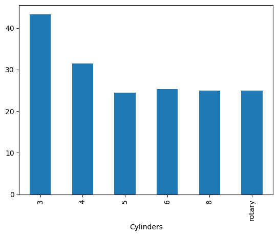

```python
###if we have to plot bar graph
P.groupby(by='Cylinders').mean()['MPG.highway'].plot(kind='bar')
```

## 4.Find out top 8 cars with highest horsepower in Compact category

```python
fil=P['Type']=='Compact'
s= P[fil]
s
```

|  | id | Manufacturer | Model | Type | Min.Price | Price | Max.Price | MPG.city | MPG.highway | AirBags | DriveTrain | Cylinders | EngineSize | Horsepower | RPM | Rev.per.mile | Man.trans.avail | Fuel.tank.capacity | Passengers | Length | Wheelbase | Width | Turn.circle | Rear.seat.room | Luggage.room | Weight | Origin | Make |
| --- | --- | --- | --- | --- | --- | --- | --- | --- | --- | --- | --- | --- | --- | --- | --- | --- | --- | --- | --- | --- | --- | --- | --- | --- | --- | --- | --- | --- |
| 2 | 3 | Audi | 90 | Compact | 25.9 | 29.1 | 32.3 | 20 | 26 | Driver only | Front | 6 | 2.8 | 172 | 5500 | 2280 | Yes | 16.9 | 5 | 180 | 102 | 67 | 37 | 28.0 | 14.0 | 3375 | non-USA | Audi 90 |
| 11 | 12 | Chevrolet | Cavalier | Compact | 8.5 | 13.4 | 18.3 | 25 | 36 | None | Front | 4 | 2.2 | 110 | 5200 | 2380 | Yes | 15.2 | 5 | 182 | 101 | 66 | 38 | 25.0 | 13.0 | 2490 | USA | Chevrolet Cavalier |
| 12 | 13 | Chevrolet | Corsica | Compact | 11.4 | 11.4 | 11.4 | 25 | 34 | Driver only | Front | 4 | 2.2 | 110 | 5200 | 2665 | Yes | 15.6 | 5 | 184 | 103 | 68 | 39 | 26.0 | 14.0 | 2785 | USA | Chevrolet Corsica |
| 20 | 21 | Chrysler | LeBaron | Compact | 14.5 | 15.8 | 17.1 | 23 | 28 | Driver & Passenger | Front | 4 | 3.0 | 141 | 5000 | 2090 | No | 16.0 | 6 | 183 | 104 | 68 | 41 | 30.5 | 14.0 | 3085 | USA | Chrysler LeBaron |
| 24 | 25 | Dodge | Spirit | Compact | 11.9 | 13.3 | 14.7 | 22 | 27 | Driver only | Front | 4 | 2.5 | 100 | 4800 | 2535 | Yes | 16.0 | 6 | 181 | 104 | 68 | 39 | 30.5 | 14.0 | 2970 | USA | Dodge Spirit |
| 32 | 33 | Ford | Tempo | Compact | 10.4 | 11.3 | 12.2 | 22 | 27 | None | Front | 4 | 2.3 | 96 | 4200 | 2805 | Yes | 15.9 | 5 | 177 | 100 | 68 | 39 | 27.5 | 13.0 | 2690 | USA | Ford Tempo |
| 42 | 43 | Honda | Accord | Compact | 13.8 | 17.5 | 21.2 | 24 | 31 | Driver & Passenger | Front | 4 | 2.2 | 140 | 5600 | 2610 | Yes | 17.0 | 4 | 185 | 107 | 67 | 41 | 28.0 | 14.0 | 3040 | non-USA | Honda Accord |
| 54 | 55 | Mazda | 626 | Compact | 14.3 | 16.5 | 18.7 | 26 | 34 | Driver only | Front | 4 | 2.5 | 164 | 5600 | 2505 | Yes | 15.5 | 5 | 184 | 103 | 69 | 40 | 29.5 | 14.0 | 2970 | non-USA | Mazda 626 |
| 57 | 58 | Mercedes-Benz | 190E | Compact | 29.0 | 31.9 | 34.9 | 20 | 29 | Driver only | Rear | 4 | 2.3 | 130 | 5100 | 2425 | Yes | 14.5 | 5 | 175 | 105 | 67 | 34 | 26.0 | 12.0 | 2920 | non-USA | Mercedes-Benz 190E |
| 64 | 65 | Nissan | Altima | Compact | 13.0 | 15.7 | 18.3 | 24 | 30 | Driver only | Front | 4 | 2.4 | 150 | 5600 | 2130 | Yes | 15.9 | 5 | 181 | 103 | 67 | 40 | 28.5 | 14.0 | 3050 | non-USA | Nissan Altima |
| 67 | 68 | Oldsmobile | Achieva | Compact | 13.0 | 13.5 | 14.0 | 24 | 31 | None | Front | 4 | 2.3 | 155 | 6000 | 2380 | No | 15.2 | 5 | 188 | 103 | 67 | 39 | 28.0 | 14.0 | 2910 | USA | Oldsmobile Achieva |
| 73 | 74 | Pontiac | Sunbird | Compact | 9.4 | 11.1 | 12.8 | 23 | 31 | None | Front | 4 | 2.0 | 110 | 5200 | 2665 | Yes | 15.2 | 5 | 181 | 101 | 66 | 39 | 25.0 | 13.0 | 2575 | USA | Pontiac Sunbird |
| 77 | 78 | Saab | 900 | Compact | 20.3 | 28.7 | 37.1 | 20 | 26 | Driver only | Front | 4 | 2.1 | 140 | 6000 | 2910 | Yes | 18.0 | 5 | 184 | 99 | 67 | 37 | 26.5 | 14.0 | 2775 | non-USA | Saab 900 |
| 81 | 82 | Subaru | Legacy | Compact | 16.3 | 19.5 | 22.7 | 23 | 30 | Driver only | 4WD | 4 | 2.2 | 130 | 5600 | 2330 | Yes | 15.9 | 5 | 179 | 102 | 67 | 37 | 27.0 | 14.0 | 3085 | non-USA | Subaru Legacy |
| 89 | 90 | Volkswagen | Passat | Compact | 17.6 | 20.0 | 22.4 | 21 | 30 | None | Front | 4 | 2.0 | 134 | 5800 | 2685 | Yes | 18.5 | 5 | 180 | 103 | 67 | 35 | 31.5 | 14.0 | 2985 | non-USA | Volkswagen Passat |
| 91 | 92 | Volvo | 240 | Compact | 21.8 | 22.7 | 23.5 | 21 | 28 | Driver only | Rear | 4 | 2.3 | 114 | 5400 | 2215 | Yes | 15.8 | 5 | 190 | 104 | 67 | 37 | 29.5 | 14.0 | 2985 | non-USA | Volvo 240 |

```python
s=s.sort_values(by='Horsepower').tail(8)
```

```python
s
```

|  | id | Manufacturer | Model | Type | Min.Price | Price | Max.Price | MPG.city | MPG.highway | AirBags | DriveTrain | Cylinders | EngineSize | Horsepower | RPM | Rev.per.mile | Man.trans.avail | Fuel.tank.capacity | Passengers | Length | Wheelbase | Width | Turn.circle | Rear.seat.room | Luggage.room | Weight | Origin | Make |
| --- | --- | --- | --- | --- | --- | --- | --- | --- | --- | --- | --- | --- | --- | --- | --- | --- | --- | --- | --- | --- | --- | --- | --- | --- | --- | --- | --- | --- |
| 89 | 90 | Volkswagen | Passat | Compact | 17.6 | 20.0 | 22.4 | 21 | 30 | None | Front | 4 | 2.0 | 134 | 5800 | 2685 | Yes | 18.5 | 5 | 180 | 103 | 67 | 35 | 31.5 | 14.0 | 2985 | non-USA | Volkswagen Passat |
| 42 | 43 | Honda | Accord | Compact | 13.8 | 17.5 | 21.2 | 24 | 31 | Driver & Passenger | Front | 4 | 2.2 | 140 | 5600 | 2610 | Yes | 17.0 | 4 | 185 | 107 | 67 | 41 | 28.0 | 14.0 | 3040 | non-USA | Honda Accord |
| 77 | 78 | Saab | 900 | Compact | 20.3 | 28.7 | 37.1 | 20 | 26 | Driver only | Front | 4 | 2.1 | 140 | 6000 | 2910 | Yes | 18.0 | 5 | 184 | 99 | 67 | 37 | 26.5 | 14.0 | 2775 | non-USA | Saab 900 |
| 20 | 21 | Chrysler | LeBaron | Compact | 14.5 | 15.8 | 17.1 | 23 | 28 | Driver & Passenger | Front | 4 | 3.0 | 141 | 5000 | 2090 | No | 16.0 | 6 | 183 | 104 | 68 | 41 | 30.5 | 14.0 | 3085 | USA | Chrysler LeBaron |
| 64 | 65 | Nissan | Altima | Compact | 13.0 | 15.7 | 18.3 | 24 | 30 | Driver only | Front | 4 | 2.4 | 150 | 5600 | 2130 | Yes | 15.9 | 5 | 181 | 103 | 67 | 40 | 28.5 | 14.0 | 3050 | non-USA | Nissan Altima |
| 67 | 68 | Oldsmobile | Achieva | Compact | 13.0 | 13.5 | 14.0 | 24 | 31 | None | Front | 4 | 2.3 | 155 | 6000 | 2380 | No | 15.2 | 5 | 188 | 103 | 67 | 39 | 28.0 | 14.0 | 2910 | USA | Oldsmobile Achieva |
| 54 | 55 | Mazda | 626 | Compact | 14.3 | 16.5 | 18.7 | 26 | 34 | Driver only | Front | 4 | 2.5 | 164 | 5600 | 2505 | Yes | 15.5 | 5 | 184 | 103 | 69 | 40 | 29.5 | 14.0 | 2970 | non-USA | Mazda 626 |
| 2 | 3 | Audi | 90 | Compact | 25.9 | 29.1 | 32.3 | 20 | 26 | Driver only | Front | 6 | 2.8 | 172 | 5500 | 2280 | Yes | 16.9 | 5 | 180 | 102 | 67 | 37 | 28.0 | 14.0 | 3375 | non-USA | Audi 90 |

```python
s=s.sort_values(by='Horsepower',ascending=False).head(8)
```

```python
s
```

|  | id | Manufacturer | Model | Type | Min.Price | Price | Max.Price | MPG.city | MPG.highway | AirBags | DriveTrain | Cylinders | EngineSize | Horsepower | RPM | Rev.per.mile | Man.trans.avail | Fuel.tank.capacity | Passengers | Length | Wheelbase | Width | Turn.circle | Rear.seat.room | Luggage.room | Weight | Origin | Make |
| --- | --- | --- | --- | --- | --- | --- | --- | --- | --- | --- | --- | --- | --- | --- | --- | --- | --- | --- | --- | --- | --- | --- | --- | --- | --- | --- | --- | --- |
| 2 | 3 | Audi | 90 | Compact | 25.9 | 29.1 | 32.3 | 20 | 26 | Driver only | Front | 6 | 2.8 | 172 | 5500 | 2280 | Yes | 16.9 | 5 | 180 | 102 | 67 | 37 | 28.0 | 14.0 | 3375 | non-USA | Audi 90 |
| 54 | 55 | Mazda | 626 | Compact | 14.3 | 16.5 | 18.7 | 26 | 34 | Driver only | Front | 4 | 2.5 | 164 | 5600 | 2505 | Yes | 15.5 | 5 | 184 | 103 | 69 | 40 | 29.5 | 14.0 | 2970 | non-USA | Mazda 626 |
| 67 | 68 | Oldsmobile | Achieva | Compact | 13.0 | 13.5 | 14.0 | 24 | 31 | None | Front | 4 | 2.3 | 155 | 6000 | 2380 | No | 15.2 | 5 | 188 | 103 | 67 | 39 | 28.0 | 14.0 | 2910 | USA | Oldsmobile Achieva |
| 64 | 65 | Nissan | Altima | Compact | 13.0 | 15.7 | 18.3 | 24 | 30 | Driver only | Front | 4 | 2.4 | 150 | 5600 | 2130 | Yes | 15.9 | 5 | 181 | 103 | 67 | 40 | 28.5 | 14.0 | 3050 | non-USA | Nissan Altima |
| 20 | 21 | Chrysler | LeBaron | Compact | 14.5 | 15.8 | 17.1 | 23 | 28 | Driver & Passenger | Front | 4 | 3.0 | 141 | 5000 | 2090 | No | 16.0 | 6 | 183 | 104 | 68 | 41 | 30.5 | 14.0 | 3085 | USA | Chrysler LeBaron |
| 42 | 43 | Honda | Accord | Compact | 13.8 | 17.5 | 21.2 | 24 | 31 | Driver & Passenger | Front | 4 | 2.2 | 140 | 5600 | 2610 | Yes | 17.0 | 4 | 185 | 107 | 67 | 41 | 28.0 | 14.0 | 3040 | non-USA | Honda Accord |
| 77 | 78 | Saab | 900 | Compact | 20.3 | 28.7 | 37.1 | 20 | 26 | Driver only | Front | 4 | 2.1 | 140 | 6000 | 2910 | Yes | 18.0 | 5 | 184 | 99 | 67 | 37 | 26.5 | 14.0 | 2775 | non-USA | Saab 900 |
| 89 | 90 | Volkswagen | Passat | Compact | 17.6 | 20.0 | 22.4 | 21 | 30 | None | Front | 4 | 2.0 | 134 | 5800 | 2685 | Yes | 18.5 | 5 | 180 | 103 | 67 | 35 | 31.5 | 14.0 | 2985 | non-USA | Volkswagen Passat |